# Logistics OTIF Performance Analytics

Supply Chain Analytics Project

2026-03-03

# Executive Summary

This project analyzes last-mile delivery performance using an Amazon delivery dataset.

The objective is to:

- Measure SLA compliance
- Identify key structural drivers of delivery time
- Quantify operational improvement impact
- Provide strategic recommendations

# Data Sources

This report reads processed datasets created by earlier scripts:

- ../data/processed/shipping_kpis.csv
- ../data/processed/model_coefficients.csv
- ../data/processed/model_fit_summary.csv
- ../data/processed/impact_summary.csv
- ../data/processed/segment_performance.csv

And visual exports:

- ../outputs/figures/*.png

# Executive KPIs

```
## # A tibble: 1 × 5
##   total_orders avg_delivery_time on_time_rate avg_delay_minutes late_orders
##          <int>             <dbl> <chr>                    <dbl>       <int>
## 1        43739              125. 58%                       19.3       18385
```

# Segment Performance Overview

```
## # A tibble: 4 × 3
##   segment worst_segment   best_segment
##   <chr>   <chr>           <chr>
## 1 area    Semi-Urban (5%) Other (74%)
## 2 traffic Jam (38%)       Low (77%)
## 3 vehicle bicycle (47%)   van (64%)
## 4 weather Cloudy (43%)    Stormy (87%)
```

# Regression Model

Model specification:

delivery_time ~ traffic + weather + vehicle + area + agent_age + agent_rating

## Model Fit

```
## # A tibble: 1 × 7
##   r.squared adj.r.squared sigma statistic p.value    df  nobs
##       <dbl>         <dbl> <dbl>     <dbl>   <dbl> <dbl> <dbl>
## 1     0.347         0.347  42.0     1364.       0    17 43685
```

## Top Drivers by Impact

```
## # A tibble: 15 × 5
##    term              estimate std.error statistic   p.value
##    <chr>                <dbl>     <dbl>     <dbl>     <dbl>
##  1 (Intercept)          245.     12.2      20.1   2.58e- 89
##  2 areaSemi-Urban        74.2     3.43     21.7   1.75e-103
##  3 trafficNaN           -53.1     4.91    -10.8   2.97e- 27
##  4 agent_rating         -38.7     0.609   -63.6   0
##  5 weatherSunny         -33.7     0.702   -48.1   0
##  6 trafficLow           -27.2     0.727   -37.4   4.13e-292
##  7 vehiclemotorcycle     25.8    11.9       2.17  2.99e-  2
##  8 weatherSandstorms    -16.1     0.697   -23.1   4.77e-117
##  9 weatherWindy         -16.0     0.698   -22.9   5.41e-115
## 10 weatherStormy        -15.9     0.694   -22.9   6.15e-115
## 11 trafficJam            15.6     0.735    21.2   3.18e- 99
## 12 areaOther            -14.4     1.27    -11.4   7.90e- 30
## 13 vehiclescooter        12.4    11.9       1.05  2.95e-  1
## 14 vehiclevan            11.5    11.9       0.971 3.32e-  1
## 15 areaUrban            -11.5     0.489   -23.6   5.51e-122
```

Interpretation:

- Positive estimate increases delivery time
- Negative estimate reduces delivery time
- Larger magnitude indicates stronger operational influence

# Business Impact Simulation

```
## # A tibble: 11 × 2
##    metric                                      value
##    <chr>                                       <dbl>
##  1 orders_total                              43739
##  2 rating_coef_minutes_per_point               -38.7
##  3 rating_improvement_assumed_points             0.5
##  4 minutes_saved_per_order_from_rating         -19.4
##  5 total_minutes_saved_from_rating         -846847.
##  6 semi_urban_coef_extra_minutes_per_order      74.2
##  7 semi_urban_orders                           152
##  8 semi_urban_total_minutes_burden           11276.
##  9 jam_coef_extra_minutes_per_order             15.6
## 10 jam_orders                                13725
## 11 jam_total_minutes_burden                 213918.
```

This quantifies:

- Time savings from improving agent rating
- Structural delay burden in Semi-Urban areas
- Traffic Jam impact

# Visual Performance Insights

## On-Time Rate by Traffic

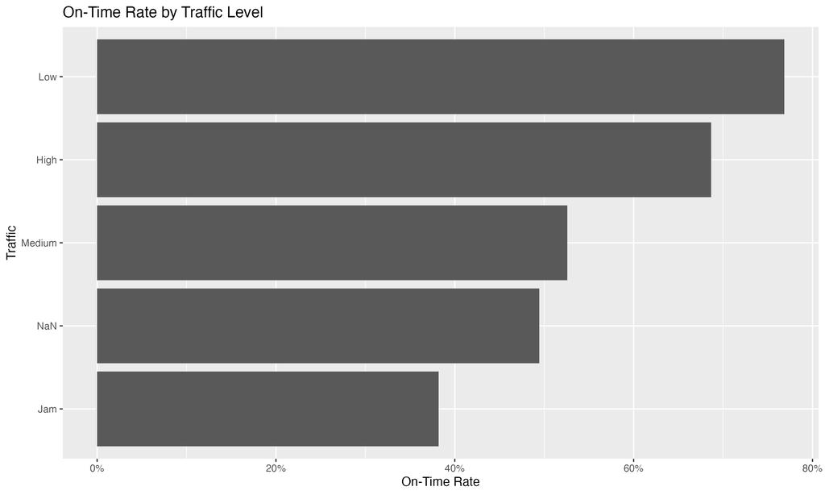

## On-Time Rate by Weather

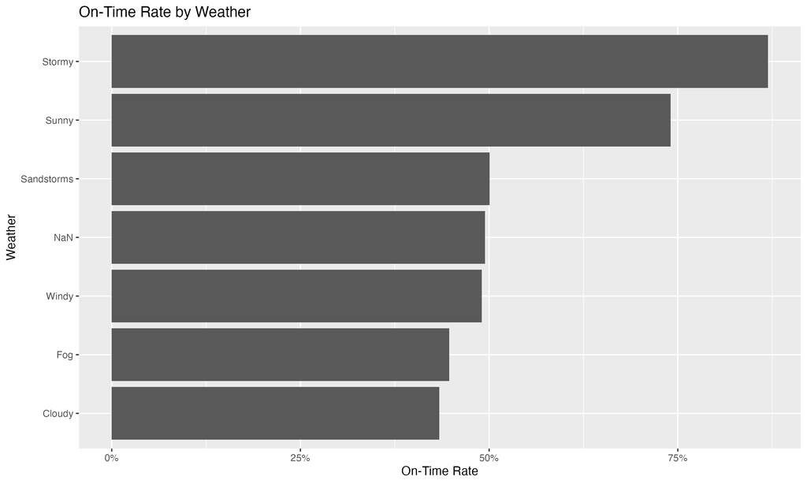

## On-Time Rate by Area

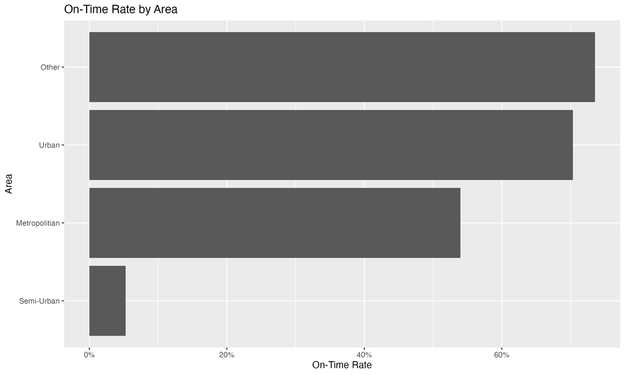

## On-Time Rate by Vehicle

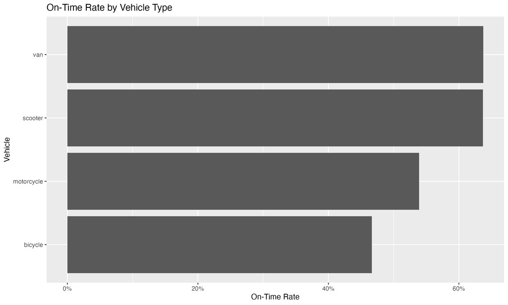

## Delivery Time Distribution

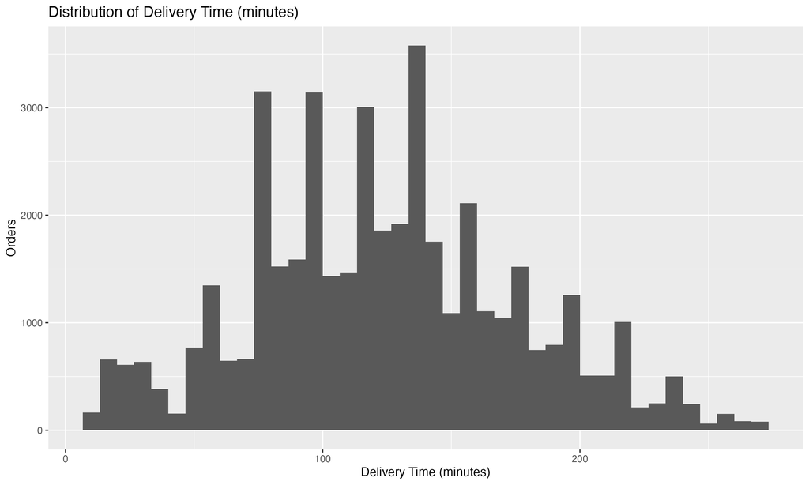

## On-Time Trend

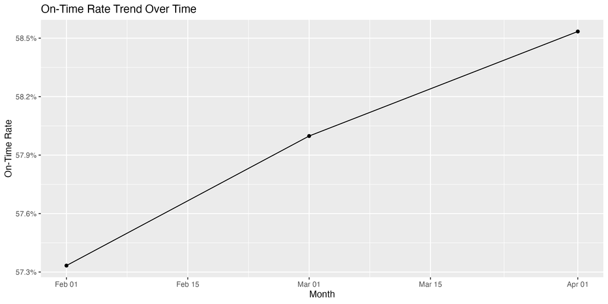

# Strategic Recommendations

1. Improve agent performance management  
   Agent rating shows strong impact on delivery time.
2. Re-structure Semi-Urban routing  
   Significant structural delay burden identified.
3. Implement traffic-aware dispatch logic  
   Jam conditions materially increase delivery time.
4. Review vehicle allocation strategy  
   Optimize vehicle use for congestion exposure.

# Conclusion

This project demonstrates a complete logistics analytics workflow:

Data Engineering  
→ KPI Definition  
→ Statistical Modeling  
→ Impact Quantification  
→ Executive Reporting

The framework mirrors real-world supply chain analytics practice and supports decision-driven performance improvement.